# Lab 5 — Practice with the gapminder Data (Problem Set 2)

Quantitative Reasoning · LAB 413

Instructor: Subin Na

October 1, 2025

> **How to use this document.** Run the code along with me. Comments start with `#`. Today we practice Problem Set 2–style tasks using the `gapminder` dataset, and we compare **dplyr** and **base R** approaches side by side.

**Today’s plan**

0. Setup: clear environment, load packages, import dataset
1. Exploring the data
2. Summary statistics & filtering
3. Correlation and regression
4. Visualization

# 1 Setup: Environment & Packages

```r
rm(list = ls())   # clean environment

# Load the packages
library(tidyverse)
library(ggplot2)
library(gapminder)
```

> In the live session we set the working directory with `setwd(...)`. In this document the data file `gapminder.csv` sits next to the `.Rmd`, so no `setwd()` is needed.

```r
gapminder <- read.csv("gapminder.csv")

# In RStudio you would run View(gapminder); here we preview the first rows.
knitr::kable(head(gapminder), caption = "First rows of the gapminder data")
```

First rows of the gapminder data

| country | continent | year | lifeExp | pop | gdpPercap |
| --- | --- | --- | --- | --- | --- |
| Afghanistan | Asia | 1952 | 28.801 | 8425333 | 779.4453 |
| Afghanistan | Asia | 1957 | 30.332 | 9240934 | 820.8530 |
| Afghanistan | Asia | 1962 | 31.997 | 10267083 | 853.1007 |
| Afghanistan | Asia | 1967 | 34.020 | 11537966 | 836.1971 |
| Afghanistan | Asia | 1972 | 36.088 | 13079460 | 739.9811 |
| Afghanistan | Asia | 1977 | 38.438 | 14880372 | 786.1134 |

```r
summary(gapminder)
```

```
#>    country           continent              year         lifeExp
#>  Length:1704        Length:1704        Min.   :1952   Min.   :23.60
#>  Class :character   Class :character   1st Qu.:1966   1st Qu.:48.20
#>  Mode  :character   Mode  :character   Median :1980   Median :60.71
#>                                        Mean   :1980   Mean   :59.47
#>                                        3rd Qu.:1993   3rd Qu.:70.85
#>                                        Max.   :2007   Max.   :82.60
#>       pop              gdpPercap
#>  Min.   :6.001e+04   Min.   :   241.2
#>  1st Qu.:2.794e+06   1st Qu.:  1202.1
#>  Median :7.024e+06   Median :  3531.8
#>  Mean   :2.960e+07   Mean   :  7215.3
#>  3rd Qu.:1.959e+07   3rd Qu.:  9325.5
#>  Max.   :1.319e+09   Max.   :113523.1
```

**Simple codebook**

| Variable | Description |
| --- | --- |
| `country` | name of the country (categorical) |
| `continent` | continent of the country (categorical) |
| `year` | year of observation, 1952–2007 (numeric) |
| `lifeExp` | life expectancy at birth in years (numeric) |
| `pop` | total population (numeric) |
| `gdpPercap` | GDP per capita (numeric) |

# 2 Exploring the Data

**(a) How many rows (observations) and columns (variables) are in the dataset?**

```r
nrow(gapminder)
```

```
#> [1] 1704
```

```r
ncol(gapminder)
```

```
#> [1] 6
```

**(b) How many unique countries are in the `country` variable?**

```r
# Base R way
length(unique(gapminder$country))
```

```
#> [1] 142
```

```r
# dplyr way
n_distinct(gapminder$country)
```

```
#> [1] 142
```

**(c) Count the number of observations for each continent.** With **dplyr** use `count()`; with **base R** use `table()`.

```r
# dplyr way
gapminder %>% count(continent)
```

| continent | n |
| --- | --- |
| Africa | 624 |
| Americas | 300 |
| Asia | 396 |
| Europe | 360 |
| Oceania | 24 |

```r
# Base R way
table(gapminder$continent)
```

```
#>
#>   Africa Americas     Asia   Europe  Oceania
#>      624      300      396      360       24
```

# 3 Summary Statistics and Filtering

**(a) In 2007, how many countries had a life expectancy (`lifeExp`) at least 80?**

```r
gapminder %>% filter(year == 2007, lifeExp >= 80) %>% count()
```

| n |
| --- |
| 13 |

**(b) What is the median life expectancy in Asia in 2007?** Remember: if a variable is a character type, wrap the value in quotes (`"Asia"`).

```r
# dplyr way
asia_med <- gapminder %>%
  filter(year == 2007, continent == "Asia") %>%
  summarize(median = median(lifeExp, na.rm = TRUE))
asia_med
```

| median |
| --- |
| 72.396 |

```r
# base R way
median(gapminder$lifeExp[gapminder$year == 2007 & gapminder$continent == "Asia"],
       na.rm = TRUE)
```

```
#> [1] 72.396
```

**(c) What is the difference in median life expectancy between Asia and Africa in 2007?**

```r
africa_med <- gapminder %>%
  filter(year == 2007, continent == "Africa") %>%
  summarize(median = median(lifeExp, na.rm = TRUE))

asia_med$median - africa_med$median
```

```
#> [1] 19.4695
```

Another way, using `subset()` in base R:

```r
asia   <- subset(gapminder, year == 2007 & continent == "Asia")
africa <- subset(gapminder, year == 2007 & continent == "Africa")

median_asia   <- median(asia$lifeExp, na.rm = TRUE)
median_africa <- median(africa$lifeExp, na.rm = TRUE)

median_asia - median_africa
```

```
#> [1] 19.4695
```

# 4 Correlation and Regression

**(a) Using 2007 data, compute the correlation between GDP per capita (`gdpPercap`) and life expectancy (`lifeExp`).** First create a dataset with only the 2007 observations, then calculate the correlation.

```r
gap07 <- gapminder %>% filter(year == 2007)
cor(gap07$gdpPercap, gap07$lifeExp, use = "complete.obs")
```

```
#> [1] 0.6786624
```

**(b) Run a simple linear regression with `lifeExp ~ gdpPercap`.**

```r
m1 <- lm(lifeExp ~ gdpPercap, data = gap07)
summary(m1)
```

```
#>
#> Call:
#> lm(formula = lifeExp ~ gdpPercap, data = gap07)
#>
#> Residuals:
#>     Min      1Q  Median      3Q     Max
#> -22.828  -6.316   1.922   6.898  13.128
#>
#> Coefficients:
#>              Estimate Std. Error t value Pr(>|t|)
#> (Intercept) 5.957e+01  1.010e+00   58.95   <2e-16 ***
#> gdpPercap   6.371e-04  5.827e-05   10.93   <2e-16 ***
#> ---
#> Signif. codes:  0 '***' 0.001 '**' 0.01 '*' 0.05 '.' 0.1 ' ' 1
#>
#> Residual standard error: 8.899 on 140 degrees of freedom
#> Multiple R-squared:  0.4606, Adjusted R-squared:  0.4567
#> F-statistic: 119.5 on 1 and 140 DF,  p-value: < 2.2e-16
```

**(c) Interpret the regression coefficients (slope and intercept).**

- **Intercept ≈ 59.6.** When GDP per capita = 0, the model predicts a life expectancy of about 59.6 years.
- **Slope ≈ 0.00064.** For every additional $1 of GDP per capita, life expectancy increases by about 0.00064 years.
- Both coefficients have *p*-values < 0.001 (`***`), so GDP per capita is a highly significant predictor of life expectancy in 2007.
- **R-squared ≈ 0.46.** About 46% of the variation in life expectancy across countries in 2007 is explained by GDP per capita alone.

# 5 Visualization

Create a scatterplot of `gdpPercap` and `lifeExp` for 2007, and add a regression line.

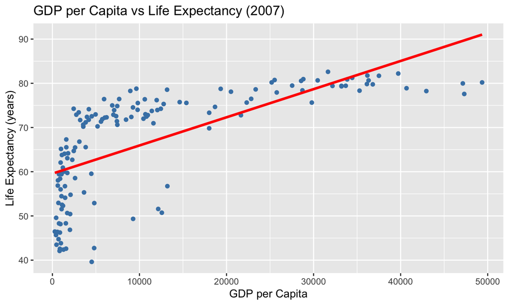

```r
ggplot(gap07, aes(x = gdpPercap, y = lifeExp)) +
  geom_point(color = "steelblue") +
  labs(
    x = "GDP per Capita",
    y = "Life Expectancy (years)",
    title = "GDP per Capita vs Life Expectancy (2007)"
  ) +
  geom_smooth(method = "lm", se = FALSE, color = "red", size = 1.2)
```

# 6 Wrap-up

**Key takeaways**

- `dplyr` verbs (`filter`, `count`, `summarize`, `%>%`) and base R (`subset`, `table`, `[ ]`) often give the same answer — pick whichever is clearer.
- Use `n_distinct()` (or `length(unique())`) to count distinct categories.
- `cor(x, y, use = "complete.obs")` handles missing values when measuring association.
- Fit a linear model with `lm(y ~ x, data = ...)` and read it with `summary()`.
- Layer a regression line onto a scatterplot with `geom_smooth(method = "lm")`.